# MIC Course

Introduction to R

Janice M. McCarthy

June 7, 2022

# Introduction to R

R is an interpreted language, which means it can be used interactively: we can type some code, hit execute and see the results instantly. This is different from compiled languages such as C or C++ where you must first compile code into an executable file, then run it.

## R as simple calculator

```r
2 + 3^5
```

```
## [1] 245
```

245

```r
7 %/% 3
```

```
## [1] 2
```

2

```r
sin(0.5*pi)
```

```
## [1] 1
```

1

```r
1.23e3
```

```
## [1] 1230
```

### Getting help

Type something and hit the tab key - this will either complete the R command for you (if unique) or present a list of opitons.

Use ?topic to get a description of `topic`, or more verbosely, you can also use `help(topic)`.

```r
?seq
```

Use example to see usage examples.

```r
example(seq)
```

```
##
## seq> seq(0, 1, length.out = 11)
##  [1] 0.0 0.1 0.2 0.3 0.4 0.5 0.6 0.7 0.8 0.9 1.0
##
## seq> seq(stats::rnorm(20)) # effectively 'along'
##  [1]  1  2  3  4  5  6  7  8  9 10 11 12 13 14 15 16 17 18 19 20
##
## seq> seq(1, 9, by = 2)     # matches 'end'
## [1] 1 3 5 7 9
##
## seq> seq(1, 9, by = pi)    # stays below 'end'
## [1] 1.000000 4.141593 7.283185
##
## seq> seq(1, 6, by = 3)
## [1] 1 4
##
## seq> seq(1.575, 5.125, by = 0.05)
##  [1] 1.575 1.625 1.675 1.725 1.775 1.825 1.875 1.925 1.975 2.025 2.075 2.125
## [13] 2.175 2.225 2.275 2.325 2.375 2.425 2.475 2.525 2.575 2.625 2.675 2.725
## [25] 2.775 2.825 2.875 2.925 2.975 3.025 3.075 3.125 3.175 3.225 3.275 3.325
## [37] 3.375 3.425 3.475 3.525 3.575 3.625 3.675 3.725 3.775 3.825 3.875 3.925
## [49] 3.975 4.025 4.075 4.125 4.175 4.225 4.275 4.325 4.375 4.425 4.475 4.525
## [61] 4.575 4.625 4.675 4.725 4.775 4.825 4.875 4.925 4.975 5.025 5.075 5.125
##
## seq> seq(17) # same as 1:17, or even better seq_len(17)
##  [1]  1  2  3  4  5  6  7  8  9 10 11 12 13 14 15 16 17
```

To search for all functions with the phrase `topic`, use `apropos(topic)`.

```r
apropos("seq")
```

```
## [1] "seq"              "seq_along"        "seq_len"          "seq.Date"
## [5] "seq.default"      "seq.int"          "seq.POSIXt"       "sequence"
## [9] "sequence.default"
```

Finally, you can always use a search engine - e.g. Googling for “how to generate random numbers from a normal distribution in R” returns: R Learning Module: Probabilities and Distributions www.ats.ucla.edu › stat › r › modules University of California, Los Angeles Generating random samples from a normal distribution … (For more information on the random number generator used in R please refer to the help pages for the …

R: The Normal Distribution https://stat.ethz.ch/R-manual/R-devel/library/…/Normal.html ETH Zurich Normal {stats}, R Documentation … quantile function and random generation for the normal distribution with mean equal to mean and … number of observations.

```r
1:4
```

```
## [1] 1 2 3 4
```

```r
seq(2, 12, 3)
```

```
## [1]  2  5  8 11
```

```r
seq(from = 0, to = pi, by = pi/4)
```

```
## [1] 0.0000000 0.7853982 1.5707963 2.3561945 3.1415927
```

```r
seq(from = 0, to = pi, length.out = 5)
```

```
## [1] 0.0000000 0.7853982 1.5707963 2.3561945 3.1415927
```

## Basic Programming Concepts

The following sections introduce some basic programming concepts within the context of R, but they are common ingredients in any programming language

```
- Style
- Variable Assignment
- Data Types
- Operators
- Looping and branching
- Errors and debugging
```

### Style

Programming style (how to name things, how much blank space to use, etc.) is an important part of creating a readable program. It’s beyond our scope to cover this in detail, but it would be a good idea to review an R style guide if you plan to write a lot of R code. Different people have slightly different conventions, but [this] (http://adv-r.had.co.nz/Style.html) guide by Hadley Wickham is pretty widely used:

### Variable Assignment

#### Assigning to variables

Variable assignments in R are made using the `<-` operator, but note that there is more than one assignment operator. Later, when we discuss custom functions in greater detail, we’ll talk about the “=” assignment operator. Note that while some programmers use “=” in place of “<-” (they are *almost* equivalent), it is considered best practice to use “<-” for assignments in R.

```r
x <- 3
y <- 5

z <- x * y

z
```

```
## [1] 15
```

#### Data Types

When we assign variables in R (and in any programming language), they are assigned a ‘type’ (implicitly or explicitly). Some common types are:

- numeric In R, this includes both floating points (decimal) and integers (e.g. 1.2, 3.14159, 15)
- integer Non-floating point number (e.g. 1, 2, -4, etc., but not 1.2, 3.14159,…)
- logical TRUE or FALSE
- character Words and letters. NB: numbers can be treated as characters too - we’ll do some examples that illustrate that.
- factor A variable that can only take a finite number of values. For example, we could have the variable eye_color, that can be blue, brown, hazel or green.

In R, these are ‘atomic’ types (also called atomic vectors, because in R, a single element is a vector of length 1). Classes (higher order structures) can be created from these basic types:

- vector A one-dimensional array with elements of one atomic type.
- matrix A 2-dimensional array with elements of one atomic type.
- list Like a vector, but elements can be anything (combination of types is allowed), even other lists.
- dataframe A 2-dimensional array that allows columns to be different types. All columns must have the same length
- tibble New version of data frame. We’ll talk more about this in future lectures.

#### Operators

Once we have variables of different types or classes, we usually want to *do* something with them. That can mean anything from simple arithmetic to summaries to custom made R functions. Here, we will discuss simple operators.

##### Arithmetic operators

- *, + , - , /

These all do what you expect to numbers (numeric types), but things get a little tricky when we have vectors and matrices. To be explicit, the above operators are multiplication, addition, subtraction and division, respectively.

- %*%

This is what is known as the ‘dot’ product for vectors and matrices.

- %%

This is the modulus operator. (When you divide an integer by another integer it returns the remainder)

- %/%

This is the integer division operator. It returns the result of a division without the remainder.

##### Logical Operators

- >, <, ==, !=, >=, <=

The above compare variables and return a ‘logical’ result (TRUE or FALSE)

- &, |

The above are ‘AND’ and ‘OR’ logical operators, respectively. We can combine the previous operators with these to form complex logical queries.

#### Examples

The only way to learn R is by using R. The following exercises require a bit more knowledge than the notes describe. Remember to use `TAB` and `?` and `apropos` whenever you’re stuck.

1. **Data Types** Define two variables of each of the following classes: numeric, character, logical and integer by assigning names (of your choice) to values (of your choice). (The integer is tricky - google or use help for this).
2. **Operators** Use the variables above to find the results of the operators *, +, -, /, %%, %/%, <, >, ==, !=, <=, >=. Which variables work with which data classes?

```r
# Your code here
```

```r
# Your code here
```

### Basic Programming continued

#### Loops and Branching

Sometimes, actually, nearly all the time, we want to repeat an operation or series of operations over many instances of a variable. For example, suppose I have a list of numbers and I want to double them all. This is a very simple example, and the first way I will show you to do it is *exactly the wrong way* in R. But we need simple examples to learn, so here we go.

There are a couple of ways to make a loop, depending on whether or not you know how many iterations will be required when you write the code.

A `for` loop is a loop that repeats over something called an iterator. The simplest example would be a count, say I want to do something 6 times. Then a `for` loop may be used. Doubling a list of known length calls for a `for` loop. (I’m kinda lying here… will clarify this in a bit.)

A `while` loop is used when conditions during execution of the code determine when the loop is terminated. Suppose we have a list of coin toss outcomes, and we want to count how many flips it took to get 3 heads. We don’t know how many iterations the loop will take, but we do have a condition for stopping.

```r
## for loop example.

v <- seq(from = 2, to = 20, by = 3)

print(v)
```

```
## [1]  2  5  8 11 14 17 20
```

```r
for (i in 1:length(v)) {
    v[i] <- 2*v[i]
}

print(v)
```

```
## [1]  4 10 16 22 28 34 40
```

The `i` in the above `for` loop is called an *iterator*. At the first step, `i` is *initialized* to 1 (because the code tells it to start at 1 and end at the length of v, with the `in 1:length(v)` statement. Each time the code in the body is executed, it is incremented (in this case, sequentially, one at a time). Iterators can be much fancier though. Here are a few examples:

```r
## for loop example

iterator_variable <- c(1,10,32,1.45)


for ( i in iterator_variable){
    print(i)
}
```

```
## [1] 1
## [1] 10
## [1] 32
## [1] 1.45
```

```r
## for loop example

iterator_variable <- list(1,10,32,1.45,"the", "quick brown fox")


for ( i in iterator_variable){
    print(i)
}
```

```
## [1] 1
## [1] 10
## [1] 32
## [1] 1.45
## [1] "the"
## [1] "quick brown fox"
```

```r
## while loop example

samples <- rbinom(100, 1, prob = 0.2)  # generate 100 Bernouli trials with success probability 0.2
i <- 0  #initialize index for samples vector


found_success <- 'FALSE'  #initialize the loop termination condition

while (found_success == 'FALSE'){
       i <- i+1
       if (samples[i] == 1)
           found_success <- 'TRUE'
}

print(samples)   # print all trials
```

```
##   [1] 0 0 0 0 0 0 0 0 1 0 0 0 1 0 0 1 0 0 0 0 0 0 0 1 0 1 0 0 0 0 0 0 0 0 1 0 0
##  [38] 0 0 0 0 0 1 0 0 1 0 0 0 0 1 0 0 1 0 0 1 0 0 0 0 0 0 0 1 1 0 0 1 0 0 0 0 0
##  [75] 0 1 0 1 0 1 1 0 0 0 0 0 0 0 0 0 0 0 0 0 0 0 0 0 0 0
```

```r
print(i)         # print index of first success.
```

```
## [1] 9
```

The above code also contains an example of ‘branching’. Branching is when the code that executes depends upon the current state of the program. In this example, the command `found_success <- 'TRUE'` only executes when the current (ith) component of `samples` is a 1.

#### Examples

1. Write a `for` loop to print the index of each success in `samples`.
2. Write a `while` loop to find the index of the third success.

### The Next Level - vectors, matrices, functions, etc.

#### Avoiding loops: Vectorization

In R, and in other scripting languages, it is usually best to avoid loops when possible. Historically, looping in interpreted languages was slow. Nowadays, the issue is more with programming style, readability and lowering the possibilty of errors.

We avoid loops by using what is called ‘vectorization’. In other words, we use functions that work on whole vectors at once, rather than one element at a time (of course, at the lowest level, the code is iterating over each element).

Many operations in R are vectorized. For example, we just used a `for` loop to double the elements of a vector. We could have done this another way:

```r
## Vectorization example

v <- seq(from = 2, to = 20, by = 3)

print(v)
```

```
## [1]  2  5  8 11 14 17 20
```

```r
print (2*v)
```

```
## [1]  4 10 16 22 28 34 40
```

R interprets the multiplication operator to do componentwise multiplication (because it’s the only thing that ‘makes sense’). Suppose we have two vectors of the same length. What does `*` do?

```r
v <- seq(from = 2, to = 20, by = 3)

w <- seq(from = 1, to = 21, by = 3)

print(v)
```

```
## [1]  2  5  8 11 14 17 20
```

```r
print(w)
```

```
## [1]  1  4  7 10 13 16 19
```

```r
print(v*w)
```

```
## [1]   2  20  56 110 182 272 380
```

R has vectorization built in to many functions. In practice, if you ever feel you need to code a loop, you should look do some googling and see if there is another way.

We’ll first talk a bit more about vectors, matrices and lists, and then we will cover some common R functions that take these as arguments.

#### Examples

1. Create the vector (1,2,3,4,5,6) using the `seq` command in R.
2. Add 2 to every element in the vector.
3. Square every element of the original vector.

#### Vectors, lists, and matrices

Linear algebra is not a pre-requisite for this course, so for our purposes, we will think of vectors as lists of numbers and matrices as two-dimensional arrays of numbers (they can also be other types, such as logical or character). They are much, much more than that, but that material is very much beyond the scope of this course. We will also mention (for those for whom it is meaningful) that vectors can be multiplied (in various ways) and matrices and vectors are related objects, and we can also multiply matrices together as well as multiply vectors and matrices.

##### Creating vectors lists and matrices

- The *concatenate* function in R builds vectors. We can also obtain vectors from other functions as we have seen in the start of these notes with the function `seq`
- Matrices are built with the command `matrix`. They can also be constructed from vectors or returned from certain functions.
- Lists are created with the `list` function.

```r
## Example of vector creation

v <- c(1,2,3,4)
print(v)
```

```
## [1] 1 2 3 4
```

```r
w <- c("This", "is", "a", "character", "vector")
print(w)
```

```
## [1] "This"      "is"        "a"         "character" "vector"
```

```r
## Example of matrix creation

## First just create a vector of entries
matrix_entries <- c(1,2,3,4,5,6,7,8,9,10,11,12)

M <- matrix(matrix_entries, ncol = 3, nrow = 4)
print(M)
```

```
##      [,1] [,2] [,3]
## [1,]    1    5    9
## [2,]    2    6   10
## [3,]    3    7   11
## [4,]    4    8   12
```

```r
matrix_entries <- c("This", "is", "a", "character", "matrix", "with", "two", "rows")
N <-  matrix(matrix_entries, nrow = 2)
print(N)
```

```
##      [,1]   [,2]        [,3]     [,4]
## [1,] "This" "a"         "matrix" "two"
## [2,] "is"   "character" "with"   "rows"
```

```r
## We can create matrices of different dimensions

N <- matrix(matrix_entries, ncol = 2, nrow = 6)
print(N)
```

```
##      [,1]        [,2]
## [1,] "This"      "two"
## [2,] "is"        "rows"
## [3,] "a"         "This"
## [4,] "character" "is"
## [5,] "matrix"    "a"
## [6,] "with"      "character"
```

```r
## add rows or columns with row bind (``rbind``) or column bind (``cbind``)

## First create a vector of the appropriate length:

new_column <- rep(1,4)

P <- cbind(M, new_column)
print(P)
```

```
##             new_column
## [1,] 1 5  9          1
## [2,] 2 6 10          1
## [3,] 3 7 11          1
## [4,] 4 8 12          1
```

#### Examples

1. Create 3 vectors, one using concatenate, one using `rep` and one using `seq`
2. Create 3 matrices: one 2x2, one 6x4, one a 4x4 with ones on the diagonal and zeroes everywhere else.
3. Use cbind and rbind to add one row and one column to the 6x4 matrix.

```r
# Your code here
```

#### Common Operations on Vectors and Matrices

Two major categories of vector operations are

- Componentwise operations
- Summary operations

We have already seen some componentwise operations (e.g. the doubling example). Let’s look at some summary operations and we will do some more componentwise in the examples.

```r
## Sum of the components of a vector

v <- c(1,2,5,8,9,10)
sum(v)
```

```
## [1] 35
```

```r
## mean

mean(v)
```

```
## [1] 5.833333
```

```r
## median

median(v)
```

```
## [1] 6.5
```

#### Examples

1. Create two vectors length 3 using the concatenate function. What happens when you add them using `+`?
2. Create a third vector of length 2. What happens if you try to add that vector to one of the others?
3. Create another vector of length 4. Add it to the vector of length 2. What do you observe?
4. We have examples of sum, mean and median summary operations. Can you find some others?
5. Try the functions `sort` and `sample`. What do they do? Try `sample` with and without replacement.

```r
## Your code here
```

#### Functions

A function is code that behaves like a black box - you give it some input and it returns some output. Functions are essential because they allow you to design potentially complicated algorithms without having to keep track of the algorithmic details - all you need to remember are the function name (which you can search with `apropos` or by prepending `??` to the search term), the input arguments (TAB provides these), and what type of output will be generated. Most of R’s usefulness comes from the large collection of functions that it provides - for example, `library()`, `seq()`, `as.fractions()` are all functions. You can also write your own R functions - this will be covered in detail in a later session - but we show the basics here.

##### Creating a function

A function has the following structure

```r
function_name <- function(arguments) {
    body_of_function
    return(result)
}
```

**function_name** is defined by the user (you). It can be anything you like, but meaningful names are encouraged to make code more readable to humans.

**function** is a keyword (one that has special meaning to R). It tells R that this is a function you are defining (as opposed to a variable).

**arguments** are inputs to the function. Usually, when you write a function, you want it to do something to a variable or variables.

**body_of_function** is a list of R commands. They are whatever you wish this function to do with the arguments.

**return** is a keyword. It tells R to send something back to the code that ‘called’ it.

**result** is user-defined. It is whatever you want R to send back to the code that called this function.

The simple example below will make this explicit.

```r
my_func <- function(a, b) {
    c <- a * b
    d <- a + 2*b
    return(d)
}
```

**function_name** is my_func

**arguments** are a and b

**body_of_function** is

```
  c <- a * b
  d <- a + 2 * b
```

**result** is d

```r
my_func(5, 4)
```

```
## [1] 13
```

```r
my_func(b = 4, a = 5)
```

```
## [1] 13
```

```r
my_func(4, 5)
```

```
## [1] 14
```

#### Examples

1. Write a function that takes as input a vector and returns a vector with each of the entries of the original vector multiplied by 3.
2. Write a function that takes as input two vectors, v and w, and returns their sum.

### Lists and Data Frames

A more general data structure in R is something called a list. Lists can have elements that are pretty much anything. For example, we can create a list of three members whose first element is a character vector, second element is a matrix and a third is a numeric vector. There is no restriction on length or type. Lists can even have other lists as elements.

This is important, because Bioconductor packages often make use of something called S4 objects. These are really just complicated lists (with functions that act on them).

#### Simple list

```r
a <- c("a", "character", "vector")
b <- matrix(1:12, nrow = 4)
c <- 2:5

print(a)
```

```
## [1] "a"         "character" "vector"
```

```r
print(b)
```

```
##      [,1] [,2] [,3]
## [1,]    1    5    9
## [2,]    2    6   10
## [3,]    3    7   11
## [4,]    4    8   12
```

```r
print(c)
```

```
## [1] 2 3 4 5
```

```r
my_list <- list(first = a, second = b, third = c)

print(my_list)
```

```
## $first
## [1] "a"         "character" "vector"
##
## $second
##      [,1] [,2] [,3]
## [1,]    1    5    9
## [2,]    2    6   10
## [3,]    3    7   11
## [4,]    4    8   12
##
## $third
## [1] 2 3 4 5
```

Notice how the elements are named. Writing “first =” names the first element ‘first’. Now, we can access elements of the list in different ways:

```r
my_list[1]
```

```
## $first
## [1] "a"         "character" "vector"
```

```r
my_list["second"]
```

```
## $second
##      [,1] [,2] [,3]
## [1,]    1    5    9
## [2,]    2    6   10
## [3,]    3    7   11
## [4,]    4    8   12
```

```r
my_list$third
```

```
## [1] 2 3 4 5
```

The ‘$’ is probably the most often used, but there is a lot of old R code out there where lists are accessed by the element number.

#### Data frames

Data frames are lists where each element has the same number of entries. This is the data structure most often seen in R code, and many functions are specialized to work on them easily. We can create one from scratch:

```r
names <- c("bast", "dash", "chestnut", "tibbs")
species <- c("cat", "cat", "dog", "dog")
ages <- c(9, 9, 7, 8)

df <- data.frame(name = names, species = species, age = ages)
df
```

```
##       name species age
## 1     bast     cat   9
## 2     dash     cat   9
## 3 chestnut     dog   7
## 4    tibbs     dog   8
```

R also has many built-in data frames that can be used to experiment or for examples.

```r
head(iris)
```

```
##   Sepal.Length Sepal.Width Petal.Length Petal.Width Species
## 1          5.1         3.5          1.4         0.2  setosa
## 2          4.9         3.0          1.4         0.2  setosa
## 3          4.7         3.2          1.3         0.2  setosa
## 4          4.6         3.1          1.5         0.2  setosa
## 5          5.0         3.6          1.4         0.2  setosa
## 6          5.4         3.9          1.7         0.4  setosa
```

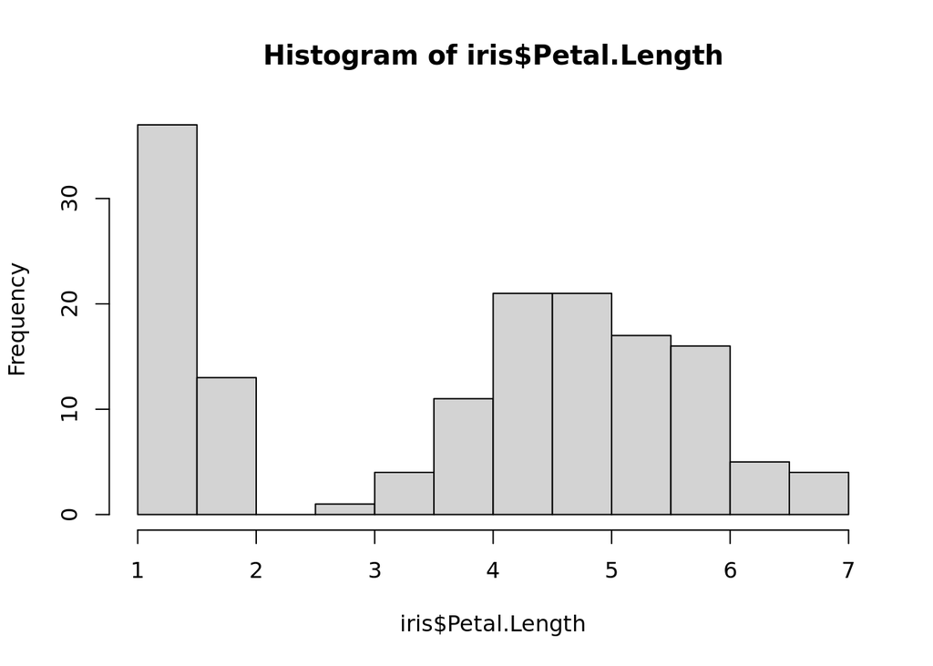

```r
hist(iris$Petal.Length)
```

#### Example

1. Explore the data frame mtcars. What variables does it contain? What are their data types?
2. Plot a histogram of the vehicle weight.